# Homework 6

PSTAT 231

2022-11-27

## Tree-Based Models

For this assignment, we will continue working with the file `"pokemon.csv"`, found in `/data`. The file is from Kaggle: https://www.kaggle.com/abcsds/pokemon.

The [Pokémon](https://www.pokemon.com/us/) franchise encompasses video games, TV shows, movies, books, and a card game. This data set was drawn from the video game series and contains statistics about 721 Pokémon, or “pocket monsters.” In Pokémon games, the user plays as a trainer who collects, trades, and battles Pokémon to (a) collect all the Pokémon and (b) become the champion Pokémon trainer.

Each Pokémon has a [primary type](https://bulbapedia.bulbagarden.net/wiki/Type) (some even have secondary types). Based on their type, a Pokémon is strong against some types, and vulnerable to others. (Think rock, paper, scissors.) A Fire-type Pokémon, for example, is vulnerable to Water-type Pokémon, but strong against Grass-type.

The goal of this assignment is to build a statistical learning model that can predict the **primary type** of a Pokémon based on its generation, legendary status, and six battle statistics.

**Note: Fitting ensemble tree-based models can take a little while to run. Consider running your models outside of the .Rmd, storing the results, and loading them in your .Rmd to minimize time to knit.**

First, we need to load the libraries needed for the homework:

```r
library(tidyverse)
library(tidymodels)
library(janitor)
library(corrplot)
library('fastDummies')
library(rpart.plot)
library(ranger)
library(vip)
library(xgboost)
```

### Exercise 1

Read in the data and set things up as in Homework 5:

- Use `clean_names()`
- Filter out the rarer Pokémon types
- Convert `type_1` and `legendary` to factors

Do an initial split of the data; you can choose the percentage for splitting. Stratify on the outcome variable.

Fold the training set using *v*-fold cross-validation, with `v = 5`. Stratify on the outcome variable.

Set up a recipe to predict `type_1` with `legendary`, `generation`, `sp_atk`, `attack`, `speed`, `defense`, `hp`, and `sp_def`:

- Dummy-code `legendary` and `generation`;
- Center and scale all predictors.

**Answer**

Now following homework 5:

```r
# Open pokemon data using `clean_names()`
pokemon <- read_csv("data/Pokemon.csv") %>%
  clean_names()

# Filter out the rare classes
pokemon_filtered <- pokemon %>%
  filter(type_1 %in% c('Bug', 'Fire', 'Grass', 'Normal', 'Water', 'Psychic'))

# Convert `type_1` and `legendary` to factors
pokemon_filtered <- pokemon_filtered %>%
  mutate(type_1 = factor(type_1), legendary = factor(legendary))

# Initial split
set.seed(3435)
pokemon_split <- initial_split(pokemon_filtered, prop = 0.70,
                               strata = type_1)
pokemon_train <- training(pokemon_split)
pokemon_test <- testing(pokemon_split)

dim(pokemon_train)
```

```
## [1] 318  13
```

```r
dim(pokemon_test)
```

```
## [1] 140  13
```

```r
# Use *v*-fold cross-validation on the training set with 5 folds
pokemon_folds <- vfold_cv(pokemon_train, strata = type_1, v = 5)
pokemon_folds
```

```
## #  5-fold cross-validation using stratification
## # A tibble: 5 × 2
##   splits           id
##   <list>           <chr>
## 1 <split [252/66]> Fold1
## 2 <split [253/65]> Fold2
## 3 <split [253/65]> Fold3
## 4 <split [256/62]> Fold4
## 5 <split [258/60]> Fold5
```

```r
# Recipe as in Homework 5
pokemon_recipe <- recipe(type_1 ~ legendary + generation + sp_atk + attack + speed + defense +
                           hp + sp_def, data = pokemon_train) %>% # Model with the predictors required
  step_dummy(all_nominal_predictors()) %>% # Dummy encode `legendary` and `generation` (only categorical)
  step_normalize(all_predictors()) # Center and scale all predictors
```

### Exercise 2

Create a correlation matrix of the training set, using the `corrplot` package. *Note: You can choose how to handle the continuous variables for this plot; justify your decision(s).*

What relationships, if any, do you notice? Do these relationships make sense to you?

**Answer**

Following previous homeworks that asked for a correlation matrix:

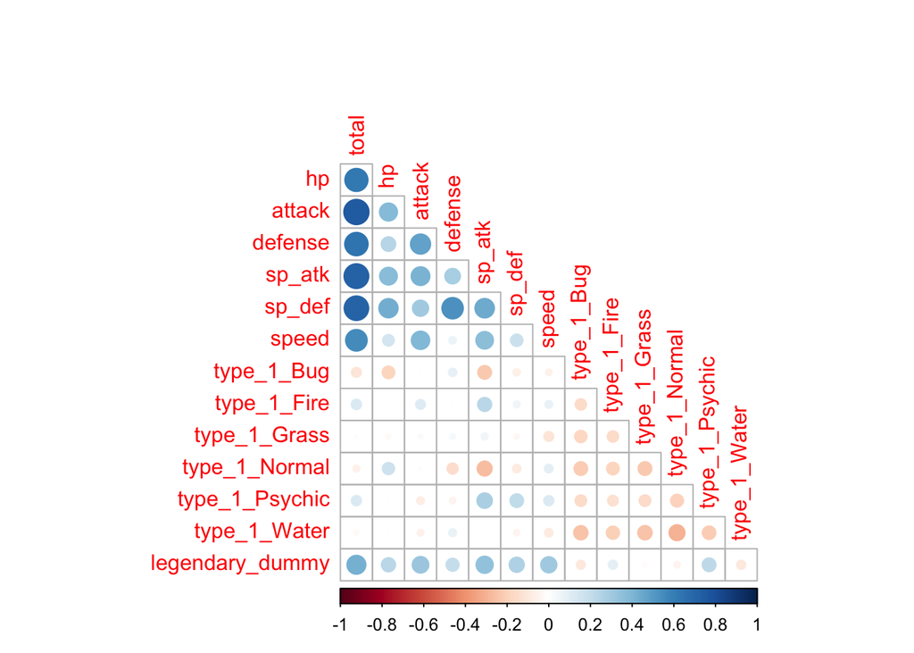

```r
pokemon_train_num <- dummy_cols(pokemon_train, select_columns = c('type_1'))
pokemon_train_num$legendary_dummy <- ifelse(pokemon_train_num$legendary == 'TRUE', 1, 0)
pokemon_train_num <- pokemon_train_num %>% select(is.numeric, -number, -generation)
correlations = cor(pokemon_train_num, use = "complete.obs")
corrplot(correlations, type = 'lower', diag = FALSE)
```

I decided to dummy code `type_1` (one dummy variable per type) and `legendary` (where 1 is equals to TRUE) because those variables are importante for us and understanding their correlation with the other variables in the data set is important. Regarding `type_2`, I excluded it as most pokemon don’t have one so it would be meaningless to include it and I also excluded `generation` because there is no reason to think that is a meaningful correlation as it is a simply order-based on the generation of pokemon they were included.

The correlation shows that `total` is positively correlation with `hp`, `attack`, `defense`, `sp_atk`, `sp_def` and `speed` which makes sense as `total` is the sum of all the other stats. Also, `total` is positively correlated with being `legendary` which also makes sense as lengedary pokemon should be more powerful.

Regarding `hp`, `attack`, `defense`, `sp_atk`, `sp_def` and `speed`, they are all positively correlated with each other but not as much as with `total`. This also makes sense as the stats of the pokemon should all move in the same direction meaning that a more powerful pokemon should have better stats separately. These stats are also positively correlated with `legendary` as expected.

### Exercise 3

First, set up a decision tree model and workflow. Tune the `cost_complexity` hyperparameter. Use the same levels we used in Lab 7 – that is, `range = c(-3, -1)`. Specify that the metric we want to optimize is `roc_auc`.

Print an `autoplot()` of the results. What do you observe? Does a single decision tree perform better with a smaller or larger complexity penalty?

**Answer**

Folling Lab 7:

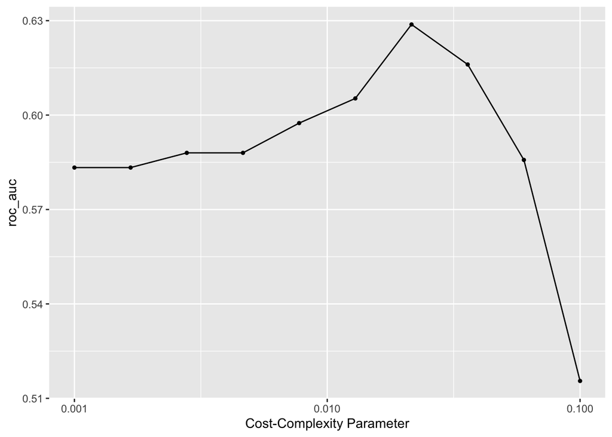

```r
tree_spec <- decision_tree() %>%
  set_engine("rpart")
class_tree_spec <- tree_spec %>%
  set_mode("classification")
class_tree_wf <- workflow() %>%
  add_model(class_tree_spec %>% set_args(cost_complexity = tune())) %>%
  add_recipe(pokemon_recipe)
param_grid <- grid_regular(cost_complexity(range = c(-3, -1)), levels = 10)
tune_res <- tune_grid(
  class_tree_wf,
  resamples = pokemon_folds,
  grid = param_grid,
  metrics = metric_set(roc_auc)
)

autoplot(tune_res)
```

The graph shows that the ROC-AUC is high for the cost-complexity paratemer values in the middle. This means that the single decision tree performs better with values in the middle rather than with very small or very large complexity penalty. It needs to be high enough (not to be really small), but not too large. One last thing is that as the cost-complexity parameter increases, the ROC-AUC increases until it reaches certain value that is too high and the the ROC-AUC goes down very fast, even below the original value of the smaller complexity penalty.

### Exercise 4

What is the `roc_auc` of your best-performing pruned decision tree on the folds? *Hint: Use `collect_metrics()` and `arrange()`.*

**Answer**

Following the previous labs and homeworks:

```r
collect_metrics(tune_res) %>% arrange(-mean)
```

```
## # A tibble: 10 × 7
##    cost_complexity .metric .estimator  mean     n std_err .config
##              <dbl> <chr>   <chr>      <dbl> <int>   <dbl> <chr>
##  1         0.0215  roc_auc hand_till  0.629     5  0.0191 Preprocessor1_Model07
##  2         0.0359  roc_auc hand_till  0.616     5  0.0202 Preprocessor1_Model08
##  3         0.0129  roc_auc hand_till  0.605     5  0.0177 Preprocessor1_Model06
##  4         0.00774 roc_auc hand_till  0.597     5  0.0187 Preprocessor1_Model05
##  5         0.00278 roc_auc hand_till  0.588     5  0.0173 Preprocessor1_Model03
##  6         0.00464 roc_auc hand_till  0.588     5  0.0173 Preprocessor1_Model04
##  7         0.0599  roc_auc hand_till  0.586     5  0.0233 Preprocessor1_Model09
##  8         0.001   roc_auc hand_till  0.583     5  0.0157 Preprocessor1_Model01
##  9         0.00167 roc_auc hand_till  0.583     5  0.0157 Preprocessor1_Model02
## 10         0.1     roc_auc hand_till  0.516     5  0.0155 Preprocessor1_Model10
```

The `roc_auc` of my best-performing pruned decision tree on the folds is 0.6287888.

### Exercise 5

Using `rpart.plot`, fit and visualize your best-performing pruned decision tree with the *training* set.

**Answer**

Following Lab 7:

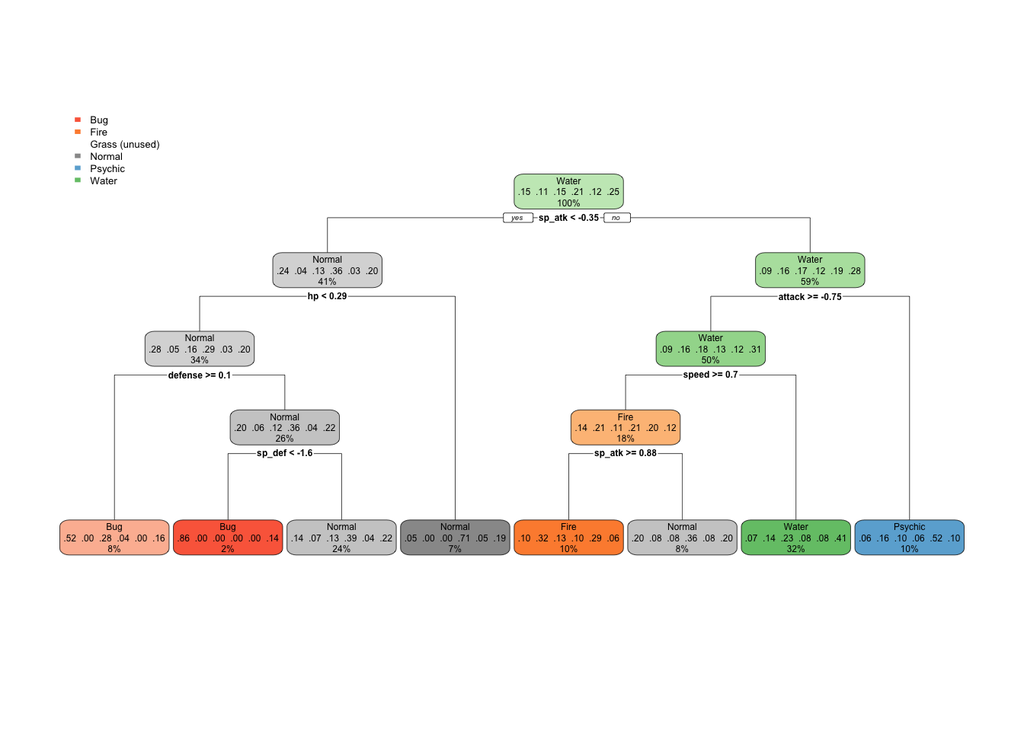

```r
# Select the best complexity
best_complexity <- select_best(tune_res)

# Fit Selected model
class_tree_final <- finalize_workflow(class_tree_wf, best_complexity)
class_tree_final_fit <- fit(class_tree_final, data = pokemon_train)

# Visualize the model
class_tree_final_fit %>%
  extract_fit_engine() %>%
  rpart.plot()
```

### Exercise 5

Now set up a random forest model and workflow. Use the `ranger` engine and set `importance = "impurity"`. Tune `mtry`, `trees`, and `min_n`. Using the documentation for `rand_forest()`, explain in your own words what each of these hyperparameters represent.

Create a regular grid with 8 levels each. You can choose plausible ranges for each hyperparameter. Note that `mtry` should not be smaller than 1 or larger than 8. **Explain why not. What type of model would `mtry = 8` represent?**

**Answer**

Following Lab 7:

```r
rf_spec <- rand_forest() %>%
  set_engine("ranger", importance = "impurity")
class_rf_spec <- rf_spec %>%
  set_mode("classification")
class_rf_wf <- workflow() %>%
  add_model(class_rf_spec %>% set_args(mtry = tune(), trees = tune(), min_n = tune())) %>%
  add_recipe(pokemon_recipe)
param_rf_grid <- grid_regular(mtry(range = c(1, 8)), trees(range = c(10, 2000)), min_n(range = c(2, 16)), levels = 8)
```

Each of these hyperparameters represent: - `mtry`: It is the number of predictors that will be chosen to be included to create the tree models. - `trees`: It is the number of trees that our model will contained. - `min_n`: It is the minimum number of observations that are needed for us to split a node in the tree.

I choose the following values for each of the hyperparameter: - `mtry`: Range from 1 to 8 (adds 1 for every level) - `trees`: Range from 10 to 2000 (adds 284 approximately for every level) - `min_n`: Range from 2 to 16 (adds 2 for every level). Here I only did up to 16 because we have a small data set.

We know that `mtry` should not be smaller than 1 because at the very least we should select one of the predictors in the tree model. If we set it to be less than one none of the predictor will be chosen and that would be a mistake. Also, `mtry` not be larger than 8 because we only have 8 predictors in our model and there is no possible way of us to choose more than that. Finally, `mtry = 8` represent a bagging model as the `mtry` is equal to the number of predictors in this random forest.

### Exercise 6

Specify `roc_auc` as a metric. Tune the model and print an `autoplot()` of the results. What do you observe? What values of the hyperparameters seem to yield the best performance?

**Answer**

```r
# Tune the results
tune_rf <- tune_grid(
  class_rf_wf,
  resamples = pokemon_folds,
  grid = param_rf_grid,
  metrics = metric_set(roc_auc)
)

# Save the results
saveRDS(tune_rf, file="tune_rf_data.RData")
```

Now we need to save the results as it takes a lot of time to run:

```r
tune_rf_saved <- readRDS("tune_rf_data.RData")
```

Now we can do the autoplot:

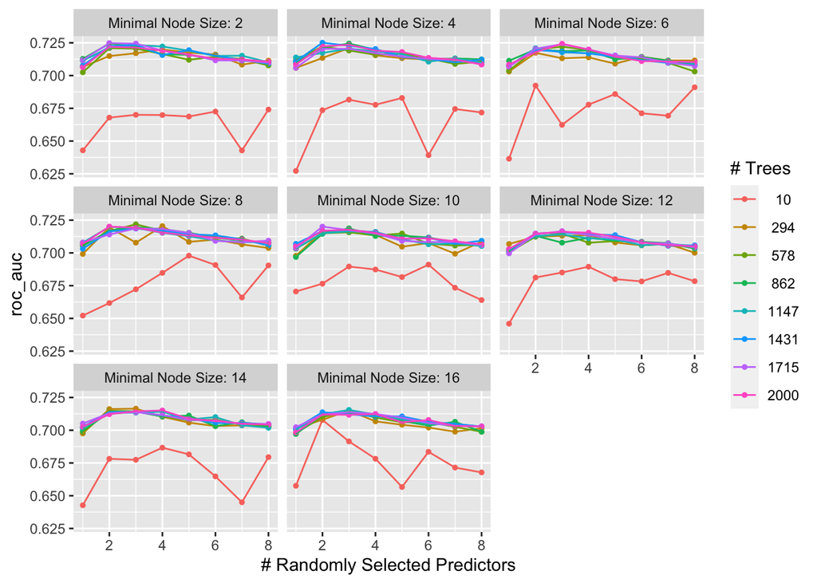

```r
autoplot(tune_rf_saved)
```

The plot shows the expected results. This is: - For `mtry`, it shows that the ROC-AUC is very low for small values of it but when we use all of them as in a bagging model, it is also small. We need a balance as we don’t want to be in the extremes and the plot suggest that `mtry = 2` yields the best performance overall all the models accounting for the values of the other two hyperparameters (`trees` and `min_n`)

### Exercise 7

What is the `roc_auc` of your best-performing random forest model on the folds? *Hint: Use `collect_metrics()` and `arrange()`.*

**Answer**

Following the previous labs and homeworks:

```r
collect_metrics(tune_rf_saved) %>% arrange(-mean)
```

```
## # A tibble: 512 × 9
##     mtry trees min_n .metric .estimator  mean     n std_err .config
##    <int> <int> <int> <chr>   <chr>      <dbl> <int>   <dbl> <chr>
##  1     2  1431     4 roc_auc hand_till  0.725     5  0.0139 Preprocessor1_Model…
##  2     2  1715     2 roc_auc hand_till  0.725     5  0.0133 Preprocessor1_Model…
##  3     3   862     4 roc_auc hand_till  0.724     5  0.0160 Preprocessor1_Model…
##  4     3  1715     2 roc_auc hand_till  0.724     5  0.0152 Preprocessor1_Model…
##  5     2   862     2 roc_auc hand_till  0.724     5  0.0138 Preprocessor1_Model…
##  6     3  2000     6 roc_auc hand_till  0.724     5  0.0164 Preprocessor1_Model…
##  7     3  1715     6 roc_auc hand_till  0.724     5  0.0165 Preprocessor1_Model…
##  8     3  1431     2 roc_auc hand_till  0.724     5  0.0148 Preprocessor1_Model…
##  9     3  2000     4 roc_auc hand_till  0.724     5  0.0155 Preprocessor1_Model…
## 10     3  1147     2 roc_auc hand_till  0.723     5  0.0151 Preprocessor1_Model…
## # … with 502 more rows
```

The `roc_auc` of my best-performing random forest model on the folds is 0.7250998.

### Exercise 8

Create a variable importance plot, using `vip()`, with your best-performing random forest model fit on the *training* set.

Which variables were most useful? Which were least useful? Are these results what you expected, or not?

**Answer**

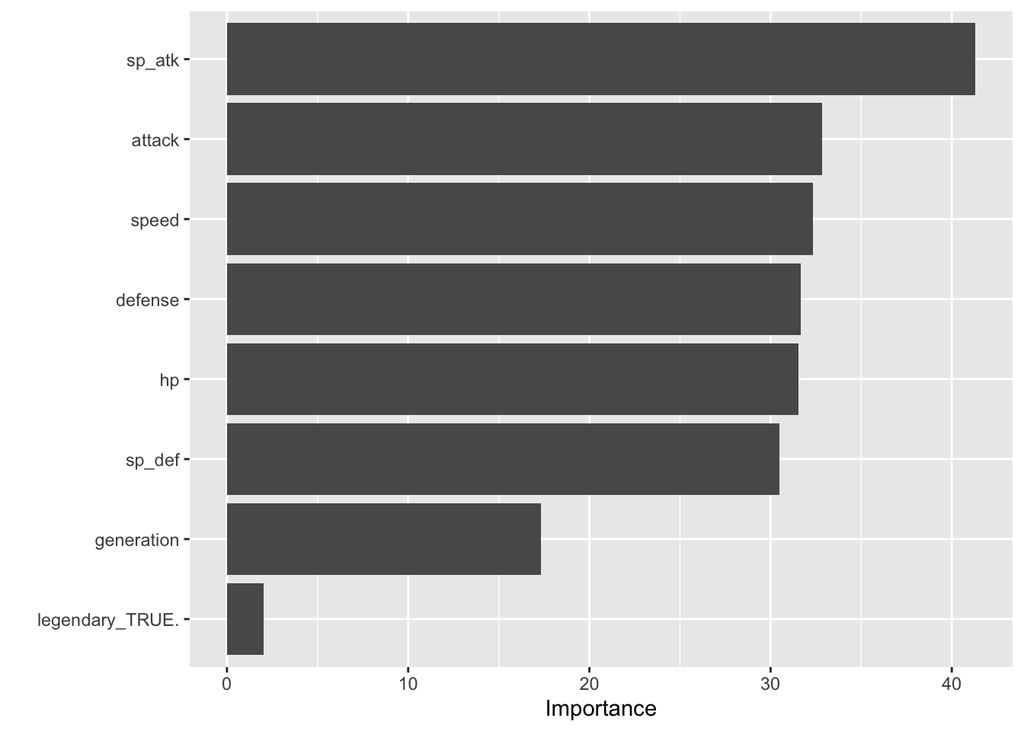

```r
# Select the best model
best_parameters <- select_best(tune_rf_saved)

# Fit Selected model
class_rf_final <- finalize_workflow(class_rf_wf, best_parameters)
class_rf_final_fit <- fit(class_rf_final, data = pokemon_train)

# Extract the results
rf_final_fit <- extract_fit_parsnip(class_rf_final_fit)$fit

# Importance plot
vip(rf_final_fit)
```

```r
pokemon_train %>%
  group_by(type_1) %>%
  summarize(MeanAttack = mean(attack),
            MeanSP_attack = mean(sp_atk))
```

```
## # A tibble: 6 × 3
##   type_1  MeanAttack MeanSP_attack
##   <fct>        <dbl>         <dbl>
## 1 Bug           73.7          56.2
## 2 Fire          84            91.8
## 3 Grass         76.2          76.3
## 4 Normal        74.8          56.9
## 5 Psychic       68.3          94.9
## 6 Water         71.2          72.3
```

### Exercise 9

Finally, set up a boosted tree model and workflow. Use the `xgboost` engine. Tune `trees`. Create a regular grid with 10 levels; let `trees` range from 10 to 2000. Specify `roc_auc` and again print an `autoplot()` of the results.

What do you observe?

What is the `roc_auc` of your best-performing boosted tree model on the folds? *Hint: Use `collect_metrics()` and `arrange()`.*

**Answer**

Following Lab 7:

```r
# Set model and grid
boost_spec <- boost_tree() %>%
  set_engine("xgboost")
class_boost_spect <- boost_spec %>%
  set_mode("classification")
class_boost_wf <- workflow() %>%
  add_model(class_boost_spect %>% set_args(trees = tune())) %>%
  add_recipe(pokemon_recipe)
param_boost_grid <- grid_regular(trees(range = c(10, 2000)), levels = 10)

# Tune model
tune_boost <- tune_grid(
  class_boost_wf,
  resamples = pokemon_folds,
  grid = param_boost_grid,
  metrics = metric_set(roc_auc)
)
```

Now I can produce the autoplot:

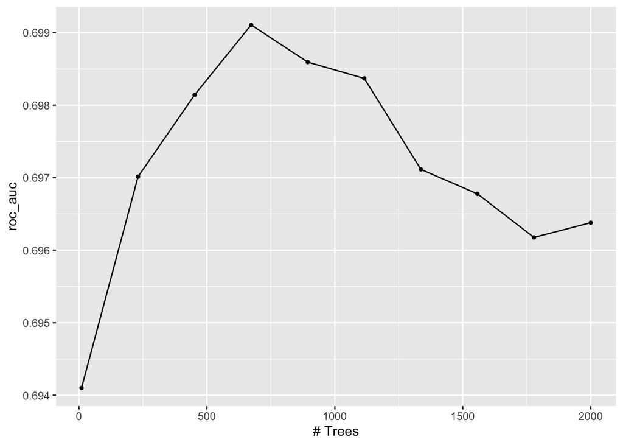

```r
autoplot(tune_boost)
```

The plot shows that as usual there needs to be a balance in the way we tune our model. in this case, having a small number of trees does not accurately represent the data and it is poteantially biased. However, having way too many of them leads possibly to overfitting and a smaller ROC-AUC. In this case, we need a number of trees of approximately 700.

Finally, we can organize the metrics to find the best-performing boosted tree model:

```r
collect_metrics(tune_boost) %>% arrange(-mean)
```

```
## # A tibble: 10 × 7
##    trees .metric .estimator  mean     n std_err .config
##    <int> <chr>   <chr>      <dbl> <int>   <dbl> <chr>
##  1   673 roc_auc hand_till  0.699     5  0.0139 Preprocessor1_Model04
##  2   894 roc_auc hand_till  0.699     5  0.0140 Preprocessor1_Model05
##  3  1115 roc_auc hand_till  0.698     5  0.0149 Preprocessor1_Model06
##  4   452 roc_auc hand_till  0.698     5  0.0134 Preprocessor1_Model03
##  5  1336 roc_auc hand_till  0.697     5  0.0154 Preprocessor1_Model07
##  6   231 roc_auc hand_till  0.697     5  0.0149 Preprocessor1_Model02
##  7  1557 roc_auc hand_till  0.697     5  0.0158 Preprocessor1_Model08
##  8  2000 roc_auc hand_till  0.696     5  0.0159 Preprocessor1_Model10
##  9  1778 roc_auc hand_till  0.696     5  0.0157 Preprocessor1_Model09
## 10    10 roc_auc hand_till  0.694     5  0.0115 Preprocessor1_Model01
```

The `roc_auc` of my best-performing boosted tree model on the folds is 0.6991073.

### Exercise 10

Display a table of the three ROC AUC values for your best-performing pruned tree, random forest, and boosted tree models. Which performed best on the folds? Select the best of the three and use `select_best()`, `finalize_workflow()`, and `fit()` to fit it to the *testing* set.

Print the AUC value of your best-performing model on the testing set. Print the ROC curves. Finally, create and visualize a confusion matrix heat map.

Which classes was your model most accurate at predicting? Which was it worst at?

**Answer**

```r
model <- c("Pruned tree","Random Forest","Boosted tree")
roc_auc_model <- c( 0.6287888, 0.7250998, 0.6991073)
tibble(model, roc_auc_model)
```

```
## # A tibble: 3 × 2
##   model         roc_auc_model
##   <chr>                 <dbl>
## 1 Pruned tree           0.629
## 2 Random Forest         0.725
## 3 Boosted tree          0.699
```

Therefore, the random forest perfoms best in the fold and we should test how it works in the testing data.

Following the labs and previous homeworks:

```r
# Select best model
best_model <- select_best(tune_rf_saved)
best_model
```

```
## # A tibble: 1 × 4
##    mtry trees min_n .config
##   <int> <int> <int> <chr>
## 1     2  1431     4 Preprocessor1_Model106
```

```r
# Fit the selected model
best_model_final <- finalize_workflow(class_rf_wf, best_model)
best_model_fit <- fit(best_model_final, data = pokemon_test)

# Evaluate its performance on the testing set
evaluate <- augment(best_model_fit, new_data = pokemon_test) %>%
  select(type_1, starts_with(".pred"))

# Print the AUC on the testing set
evaluate %>% roc_auc(type_1, .pred_Bug:.pred_Water)
```

```
## # A tibble: 1 × 3
##   .metric .estimator .estimate
##   <chr>   <chr>          <dbl>
## 1 roc_auc hand_till       1.00
```

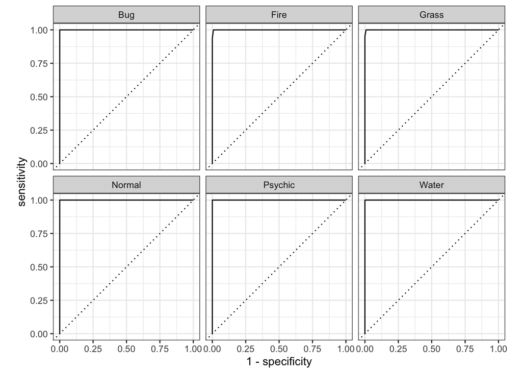

```r
# Plots of the different ROC curves
evaluate %>% roc_curve(type_1, .pred_Bug:.pred_Water) %>%
  autoplot()
```

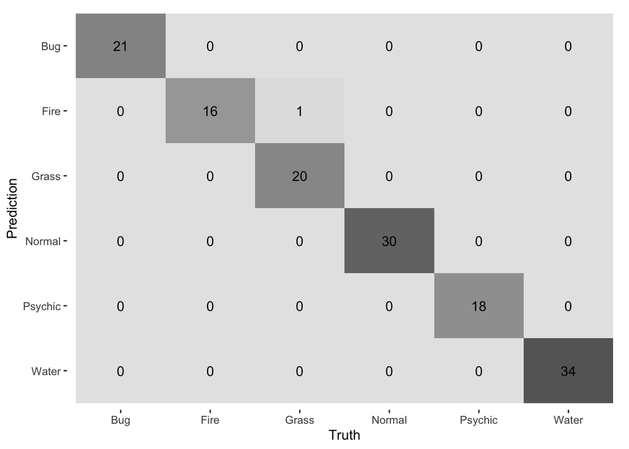

```r
# Heat map of the confusion matrix
evaluate %>% conf_mat(truth = type_1, estimate = .pred_class) %>%
  autoplot(type = "heatmap")
```

## For 231 Students

### Exercise 11

Using the `abalone.txt` data from previous assignments, fit and tune a random forest model to predict `age`. Use stratified cross-validation and select ranges for `mtry`, `min_n`, and `trees`. Present your results. What was the model’s RMSE on your testing set?

**Answer**

```r
# Load the dataset
abalone <- read_csv(file = "data/abalone.csv")

# Create age
abalone <- abalone %>%
  mutate(age = rings + 1.5)

# Data splits
set.seed(3435)
abalone_split <- initial_split(abalone, prop = 0.80,
                               strata = age)
abalone_train <- training(abalone_split)
abalone_test <- testing(abalone_split)

# Recipe as in Homework 2
abalone_recipe <- recipe(age ~ ., data = abalone_train) %>%
  step_rm(rings) %>% # Remove `rings` (step 0)
  step_dummy(all_nominal_predictors()) %>% # Dummy-code all categorical variables (step 1)
  step_interact(~ starts_with("type"):shucked_weight + # Interaction between`type` and `shucked_weight` using the dummies for type (step 2)
                  longest_shell:diameter + # Interaction between `longest_shell` and `diameter` (step 2)
                  shucked_weight:shell_weight) %>% # Interaction between `shucked_weight` and `shell_weight` (step 2)
  step_normalize(all_predictors()) # Center and scale (steps 3 and 4)

# Use *v*-fold cross-validation on the training set with 10 folds (stratified by age)
abalone_folds <- vfold_cv(abalone_train, strata = age, v = 10)
abalone_folds
```

```
## #  10-fold cross-validation using stratification
## # A tibble: 10 × 2
##    splits             id
##    <list>             <chr>
##  1 <split [3004/336]> Fold01
##  2 <split [3005/335]> Fold02
##  3 <split [3005/335]> Fold03
##  4 <split [3005/335]> Fold04
##  5 <split [3005/335]> Fold05
##  6 <split [3006/334]> Fold06
##  7 <split [3007/333]> Fold07
##  8 <split [3007/333]> Fold08
##  9 <split [3008/332]> Fold09
## 10 <split [3008/332]> Fold10
```

```r
# Set Random Forest model and regular grid (same ranges and levels as before)
abalone_spec <- rand_forest() %>%
  set_engine("ranger", importance = "impurity") %>%
  set_mode("regression")
abalone_wf <- workflow() %>%
  add_model(abalone_spec %>% set_args(mtry = tune(), trees = tune(), min_n = tune())) %>%
  add_recipe(abalone_recipe)
abalone_grid <- grid_regular(mtry(range = c(1, 8)), trees(range = c(10, 2000)), min_n(range = c(2, 80)), levels = 8)
```

*Note: Given that the sample size of the abalone data is bigger than the pokemon one. I decided to try a different range for min_n to allow for more observations*

Now we can tune the model and save it:

```r
# Tune the results
abalone_rf <- tune_grid(
  abalone_wf,
  resamples = abalone_folds,
  grid = abalone_grid
)

# Save the results
saveRDS(abalone_rf, file="abalone_rf_data.RData")
```

Now we need to save the results as it takes a lot of time to run:

```r
abalone_rf_saved <- readRDS("abalone_rf_data.RData")
```

Now we can do the autoplot:

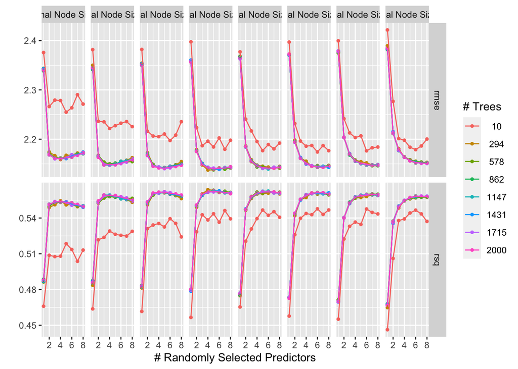

```r
autoplot(abalone_rf_saved)
```

```r
collect_metrics(abalone_rf_saved) %>% filter(.metric == "rmse") %>% arrange(mean)
```

```
## # A tibble: 512 × 9
##     mtry trees min_n .metric .estimator  mean     n std_err .config
##    <int> <int> <int> <chr>   <chr>      <dbl> <int>   <dbl> <chr>
##  1     4   294    35 rmse    standard    2.14    10  0.0425 Preprocessor1_Model…
##  2     5   294    35 rmse    standard    2.14    10  0.0424 Preprocessor1_Model…
##  3     5   862    35 rmse    standard    2.14    10  0.0420 Preprocessor1_Model…
##  4     6  1431    35 rmse    standard    2.14    10  0.0420 Preprocessor1_Model…
##  5     5  1147    35 rmse    standard    2.14    10  0.0421 Preprocessor1_Model…
##  6     7   578    35 rmse    standard    2.14    10  0.0415 Preprocessor1_Model…
##  7     5  2000    35 rmse    standard    2.14    10  0.0422 Preprocessor1_Model…
##  8     6  1147    46 rmse    standard    2.14    10  0.0425 Preprocessor1_Model…
##  9     5  1431    35 rmse    standard    2.14    10  0.0415 Preprocessor1_Model…
## 10     6  1147    35 rmse    standard    2.14    10  0.0417 Preprocessor1_Model…
## # … with 502 more rows
```

Now we can select the best model and fit it in the testing set:

```r
# Select best model
best_abalone <- select_best(abalone_rf_saved, metric = "rmse")
best_abalone
```

```
## # A tibble: 1 × 4
##    mtry trees min_n .config
##   <int> <int> <int> <chr>
## 1     4   294    35 Preprocessor1_Model204
```

```r
# Fit the selected model
best_abalone_final <- finalize_workflow(abalone_wf, best_abalone)
best_abalone_fit <- fit(best_abalone_final, data = abalone_test)

# Evaluate its performance on the testing set
evaluate_abalone <- augment(best_abalone_fit, new_data = abalone_test) %>%
  select(age, starts_with(".pred"))

# Print the AUC on the testing set
evaluate_abalone %>% rmse(age, .pred)
```

```
## # A tibble: 1 × 3
##   .metric .estimator .estimate
##   <chr>   <chr>          <dbl>
## 1 rmse    standard        1.74
```